# Tutorial 8: Advanced Topics

DPI R Bootcamp

Jared Knowles

# Overview

In this lesson we hope to learn: - Coding Style - Write a `for' loop - Write a basic function - Optimize R with parallelization - Mixed effect models - Data mining with R - Animations - Git, GitHub, and add-on packages

# Basic Principles

- Good professional data analysis is computer programming
- An analysis project is computer code
- Computer code has bugs and to fight bugs the code has to be readable

# Coding Style

- An important part of making work reproducible is making your code readable and understandable
- Much of this involves looking into where to break lines and how to simplify expressions without making them obscure
- You can also take some cues about how to make your code consistent and clean from reading code of others on GitHub
- A few tips help though

# For Looping

- Don't do it for reasons we have discussed, R is very slow at these
- Sometimes it is inevitable, so here is how to do it:

```r
# Loop to calculate number of students per grade

nstudents <- rep(NA, 6)
for (i in unique(df$grade)) {
    nstudents[[i - 2]] <- length(df$stuid[df$grade == i])
}
nstudents
```

```
## [1] 500 400 500 400 500 400
```

```r
summary(factor(df$grade))
```

```
##   3   4   5   6   7   8
## 500 400 500 400 500 400
```

# Why is a loop slow?

- Run a simple test [from StackOverflow](http://stackoverflow.com/questions/7142767/why-are-loops-slow-in-r)

```r
A = matrix(as.numeric(1:1e+05))

system.time({
    Sum = 0
    for (i in seq_along(A)) {
        Sum = Sum + A[[i]]
    }
    Sum
})
```

```
##    user  system elapsed
##    0.33    0.00    0.40
```

```r
system.time({
    sum(A)
})
```

```
##    user  system elapsed
##       0       0       0
```

```r
rm(A)
```

# Write a simple function

- Functions are easy
- To view any function in R just type `print(myfunction)`
- For speed, some functions are not viewable because they are bytecompiled

```r
print(mean)  #bytecode, we can't see it
```

```
## function (x, ...)
## standardGeneric("mean")
## <environment: 0x000000001178e870>
## attr(,"generic")
## [1] "mean"
## attr(,"generic")attr(,"package")
## [1] "base"
## attr(,"package")
## [1] "base"
## attr(,"group")
## list()
## attr(,"valueClass")
## character(0)
## attr(,"signature")
## [1] "x"
## attr(,"default")
## Method Definition (Class "derivedDefaultMethod"):
##
## function (x, ...)
## UseMethod("mean")
## <bytecode: 0x000000000920dd98>
## <environment: namespace:base>
##
## Signatures:
##         x
## target  "ANY"
## defined "ANY"
## attr(,"skeleton")
## function (x, ...)
## UseMethod("mean")(x, ...)
## attr(,"class")
## [1] "standardGeneric"
## attr(,"class")attr(,"package")
## [1] "methods"
```

```r
print(order)
```

```
## function (..., na.last = TRUE, decreasing = FALSE)
## {
##     z <- list(...)
##     if (any(unlist(lapply(z, is.object)))) {
##         z <- lapply(z, function(x) if (is.object(x))
##             xtfrm(x)
##         else x)
##         if (!is.na(na.last))
##             return(do.call("order", c(z, na.last = na.last, decreasing = decreasing)))
##     }
##     else if (!is.na(na.last))
##         return(.Internal(order(na.last, decreasing, ...)))
##     if (any(diff(l.z <- vapply(z, length, 1L)) != 0L))
##         stop("argument lengths differ")
##     ans <- vapply(z, is.na, rep.int(NA, l.z[1L]))
##     ok <- if (is.matrix(ans))
##         !apply(ans, 1, any)
##     else !any(ans)
##     if (all(!ok))
##         return(integer())
##     z[[1L]][!ok] <- NA
##     ans <- do.call("order", c(z, decreasing = decreasing))
##     keep <- seq_along(ok)[ok]
##     ans[ans %in% keep]
## }
## <bytecode: 0x000000000892ff20>
## <environment: namespace:base>
```

# Still, we can write a number of simple functions very quickly

- Let's write a function to turn factors into characters
- Because typing `x<-as.character(x)` is really obnoxious

```r
defac <- function(x) {
    # assign function a name, and list its arguments
    x <- as.character(x)  # what does function do?
    x  # last line is output of function
}

a <- factor(letters)
summary(a)
summary(defac(a))
summary(as.character(a))
```

[output not shown]

# Simple Data Cleaning Function

```r
extractN <- function(x) {
    x <- suppressWarnings(as.numeric(x))
    # ignore warnings because we don't care
    x <- x[!is.na(x)]
    x
}
foo <- c(1, 4, 3, NA, 5, 60, NA)
extractN(foo)
```

```
## [1]  1  4  3  5 60
```

```r
A <- extractN(foo)
```

# Complicating Functions

- Functions can have many arguments and be much more complex
- They can also be incredibly specialized--remember we are writing code for us!

# Mixed Effect Models

- Mixed effect models, or random effect models, are a staple for analyzing data that exists in groups (like students in classrooms)
- The underlying belief is that observations in the same group, to some degree, look more like one another than would be randomly expected (or than members of the other group)
- Random effects help us measure and parse out this similarity to avoid it biasing our statistical model (fixed effects is another alternative)
- In R we use the `lme4` package to do this work, or in a Bayesian framework (*fancy*) we can use winBUGS or JAGS
- We'll stick with `lme4` by Doug Bates (a retired UW-Madison Professor of Statistics)

# The Basics of lme4

`mymod_me<-lmer(readSS~factor(grade)+factor(race)+female+disab+ell+(1|dist)+(1|stuid),data=df)`

- items in `(1|dist)` denote a random effect. In this case we are measuring a random effect for the variable `dist` in our data.
- Otherwise the formula is the same as a regular `lm` formula (by design
- The output is tricky to interpret, but a basic mixed model is more accurate than the non-mixed version of the model (at least in nested school/district student test data)

```r
library(lme4)
mymod_me <- lmer(readSS ~ factor(grade) + factor(race) + female + disab + ell +
    (1 | dist) + (1 | stuid), data = df)
print(mymod_me, correlation = FALSE)
```

```
## Linear mixed model fit by REML
## Formula: readSS ~ factor(grade) + factor(race) + female + disab + ell +      (1 | dist) + (1 | stuid)
##    Data: df
##    AIC   BIC logLik deviance REMLdev
##  30731 30826 -15350    30774   30699
## Random effects:
##  Groups   Name        Variance Std.Dev.
##  stuid    (Intercept) 10626    103.1
##  dist     (Intercept)   487     22.1
##  Residual              1564     39.5
## Number of obs: 2700, groups: stuid, 1200; dist, 3
##
## Fixed effects:
##                Estimate Std. Error t value
## (Intercept)      378.24      31.03    12.2
## factor(grade)4    62.72       3.05    20.6
## factor(grade)5   124.67       3.28    38.0
## factor(grade)6   182.67       3.99    45.8
## factor(grade)7   236.64       4.20    56.4
## factor(grade)8   301.41       4.74    63.5
## factor(race)B    -61.87      28.05    -2.2
## factor(race)H    -34.29      27.54    -1.2
## factor(race)I     -6.09      43.93    -0.1
## factor(race)W     10.37      28.00     0.4
## female             8.76       6.21     1.4
## disab             -5.26       8.50    -0.6
## ell              -18.81      13.10    -1.4
```

# LMER vs. LM

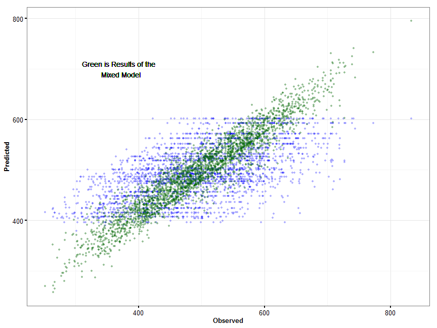

```r
mymod <- lm(readSS ~ factor(grade) + factor(race) + female + disab + ell, data = df)

qplot(readSS, predict(mymod), data = df, alpha = I(0.3), color = I("blue")) +
    geom_point(aes(x = df$readSS, y = fitted(mymod_me)), alpha = I(0.4), color = "dark green") +
    theme_dpi() + xlab("Observed") + ylab("Predicted") + geom_text(aes(x = 370,
    y = 700), label = "Green is Results of the \n Mixed Model")
```

# Data Mining with R

- When prediction is all that matters and we do not need to understand the *what* of prediction, just to accurately classify groups, then `caret` provides best in class data mining tools to us
- More and more data miners in competitions, industry, and high stakes settings are using algorithms programmed and developed in R to do their work
- We don't have time to fully implement such an analysis here, but just show what a typical workflow for the `caret` package looks like

# Using the caret

```r
library(caret)
# Set aside test set
testset <- sample(unique(df$stuid), 500)
df$case <- 0
df$case[df$stuid %in% testset] <- 1
# Draw a training set of data (random subset of students)
training <- subset(df, case == 0)
testing <- subset(df, case == 1)

training <- training[, c(3, 6:16, 21, 22, 28, 29, 30)]  # subset vars
trainX <- training[, 1:15]
refac <- function(x) as.factor(as.character(x))
trainX$stuid <- refac(trainX$stuid)
trainX$dist <- refac(trainX$dist)
trainX$year <- refac(trainX$year)

# Parameters
ctrl <- trainControl(method = "repeatedcv", number = 7, repeats = 3, summaryFunction = defaultSummary)
# Search grid
grid <- expand.grid(.interaction.depth = seq(2, 6, by = 1), .n.trees = seq(200,
    700, by = 100), .shrinkage = c(0.05, 0.1))
# Boosted tree search
gbmTune <- train(x = trainX, y = training$mathSS, method = "gbm", metric = "RMSE",
    trControl = ctrl, tuneGrid = grid, verbose = FALSE)

# gbmPred<-predict(gbmTune,testing[,names(trainX)])
```

# Plot GBM

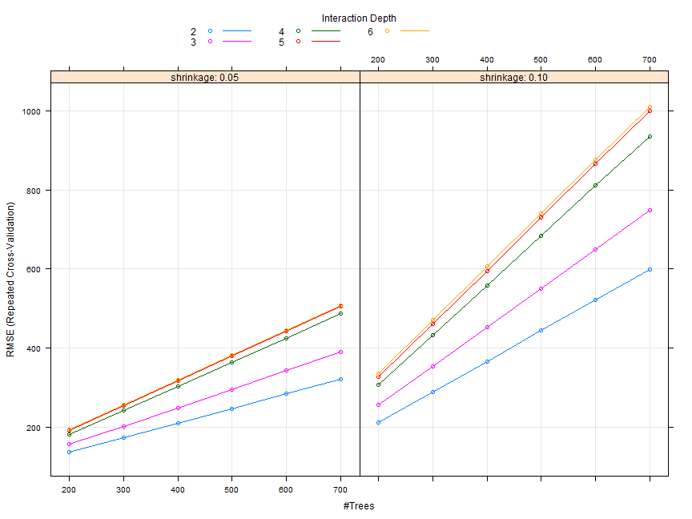

```r
plot(gbmTune)
```

# Optimizing R

- For **big** data problems, sometimes R can be a little slow
- There are two ways to speed R up--compiling code on the fly and running code in parallel
- Compiling code turns our function into **bytecode** which can be executed by the computer faster
- Running parallel uses the multiple *processor cores* in just about every modern PC to simultaneously calculate parts of a problem
- Unfortunately, when you write your code in parallel it really depends on what operating system you are using since different functions to do parallel work are set up differently on each OS

# A Quick Windows Parallel Example

```r
n <- 10000
rep <- 5
# tLoop <- replicate(rep, system.time( integLoop(func, xint, yint, n) ))
# summary(tLoop[3,])
tVec <- replicate(rep, system.time(integVec(func, xint, yint, n)))
summary(tVec[3, ])
```

```
##    Min. 1st Qu.  Median    Mean 3rd Qu.    Max.
##   0.000   0.000   0.000   0.008   0.020   0.020
```

```r
tApply <- replicate(rep, system.time(integApply(func, xint, yint, n)))
summary(tApply[3, ])
```

```
##    Min. 1st Qu.  Median    Mean 3rd Qu.    Max.
##    22.3    23.8    24.3    24.6    25.8    26.8
```

```r
# 2 Core Cluster
library(snow)
c1 <- makeCluster(c("localhost", "localhost"), type = "SOCK")
tSnow1 <- replicate(rep, system.time(integSnow(c1, func, xint, yint, n)))
summary(tSnow1[3])
```

```
##    Min. 1st Qu.  Median    Mean 3rd Qu.    Max.
##    25.7    25.7    25.7    25.7    25.7    25.7
```

```r
stopCluster(c1)
```

# Animations

- R can produce animated plots as well
- Though animations get a bad rap in the data visualization community, they can be effective at illustrating things to users
- Requires GMCONVERT and FFMPEG and potentially other tools

# Animating a Random Normal Distribution

[figure not shown]

# Git and GitHub

- Working alone or in a group, `git` and GitHub can help
- [Learn Git and GitHub](http://try.github.com/)
- Just try GitHub for a project, it is a great way to organize code
- Of course, you can find all these tutorials [on GitHub](http://www.github.com/jknowles/r_tutorial_ed)

# Exercises

1. Enjoy R!!!!

# References

1. [Technical Report on Parallel Computing in R](http://dirk.eddelbuettel.com/papers/parallelR_techRep.pdf)

# Session Info

It is good to include the session info, e.g. this document is produced with **knitr** version 0.9.6. Here is my session info:

[session information not shown]

# Attribution and License

This work (R Tutorial for Education, by Jared E. Knowles), in service of the [Wisconsin Department of Public Instruction](http://www.dpi.wi.gov), is free of known copyright restrictions.